# The sf package

Kamal

5/20/2019

# Goals With Spatial Features

1. Getting to Know GIS
2. Introducing the sf package
3. Example

# Getting To Know GIS

Geographic Information Systems - Framework of capturing, storing, manipulating, analyzing, managing, and presenting spatial data + Features - The geometry of a shape, bits of points that comprise its structure on given place on Earth

- Spatial Data - Data identifies geoprahical location
- Attribute Data - Data that identifies characteristics of locations
- Shapefiles - Geometric shape of spatial data
  - **NOTE** - MUST BE KEPT IN SAME FOLDER of supporting files
- Choropleth - Thematic map with areas of study site shaded in proportion to values of an area

# Introducing the sf package

The sf, short for **simple features**, package allows analysts to process and analyze geospatial data in R, noted by tibbles/data.frames with the **geometry column**

- Importing/Exporting shapefiles
- Creating choropleths
- Works well with ggplot2 syntax

# Example

You’re analyzing disparities of income levels across New York City and want to use a choropleth to visualize that

## What will we need?

- New York City Shapefile (Community District Level)
- New York City Median Incomes (Community District Level)

## How will we actually make one?

1. Read in our shapefile, and dataset
2. Merge them together
3. Visualize the map using ggplot syntax

## Step 1 - Reading In Shapefile/Data

Here is where is where read in the shapefile and dataset

```r
install.packages("sf")
```

```r
library(sf)

#Reading From File
NycCommunityDistricts <- read_sf("/filpath/shapefilename.shp")

#Reading From Website
NycCommunityDistricts <- read_sf("https://data.cityofnewyork.us/api/geospatial/yfnk-k7r4?method=export&format=GeoJSON")

#Load in Income Levels
NYCIncome <- fread("https://raw.githubusercontent.com/kamalabdel97/FinalPresentation/master/Median%20Incomes.csv")
```

`read_sf` - Reads in simple features

# New York Stand Up!

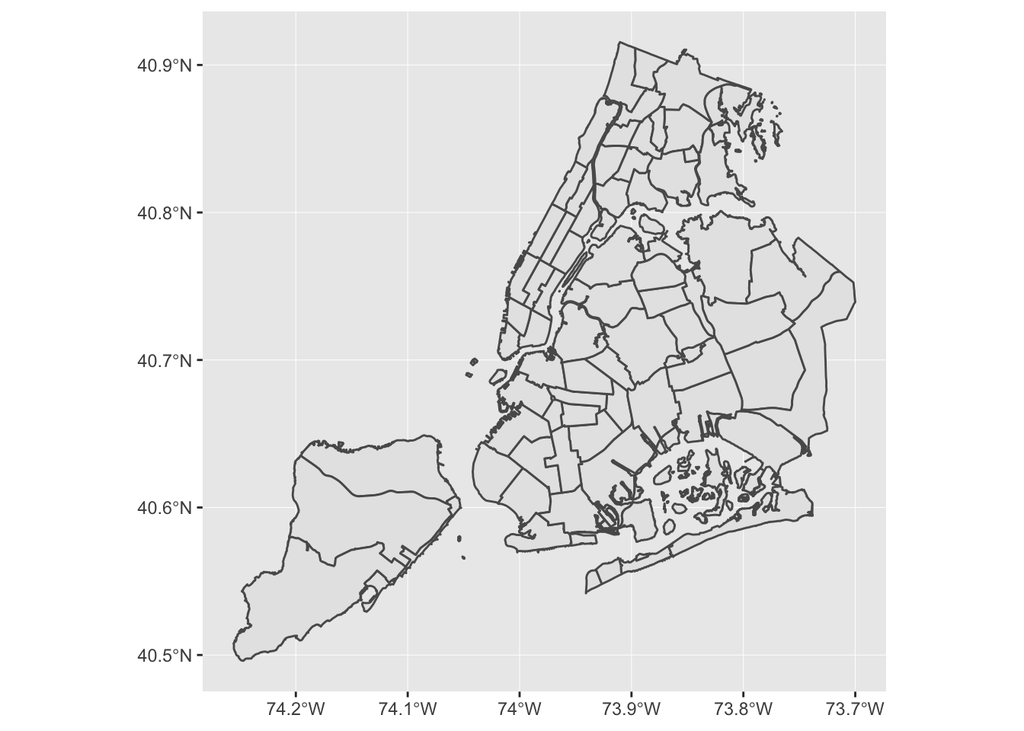

# Step 2 - Joining the data to the shapefile

```r
NycCommunityDistrictsIncome <- merge(NycCommunityDistricts, NYCIncome, by.x = "boro_cd", by.y = "Fips", all.x = T)
```

`NycCommunityDistricts` - The shapefile of the New York City community districts

`NYCIncome` - The attribute data contain the income levels

# Step 3 - Making the choropleth

```r
ggplot() +
  geom_sf(data = NycCommunityDistrictsIncome,
  aes(fill = Income))
```

`ggplot` - Invokes the ggplot syntax for data visualization

`geom_sf` - Visualizes the shapefile feature * `NycCommunityDistrictsIncome` - The shapefile dataframe containing BOTH the shapefile (spatial) and income levels (attribute)

- `Income` - The statistical value in the shapefile dataframe for each community district

# Final Map!

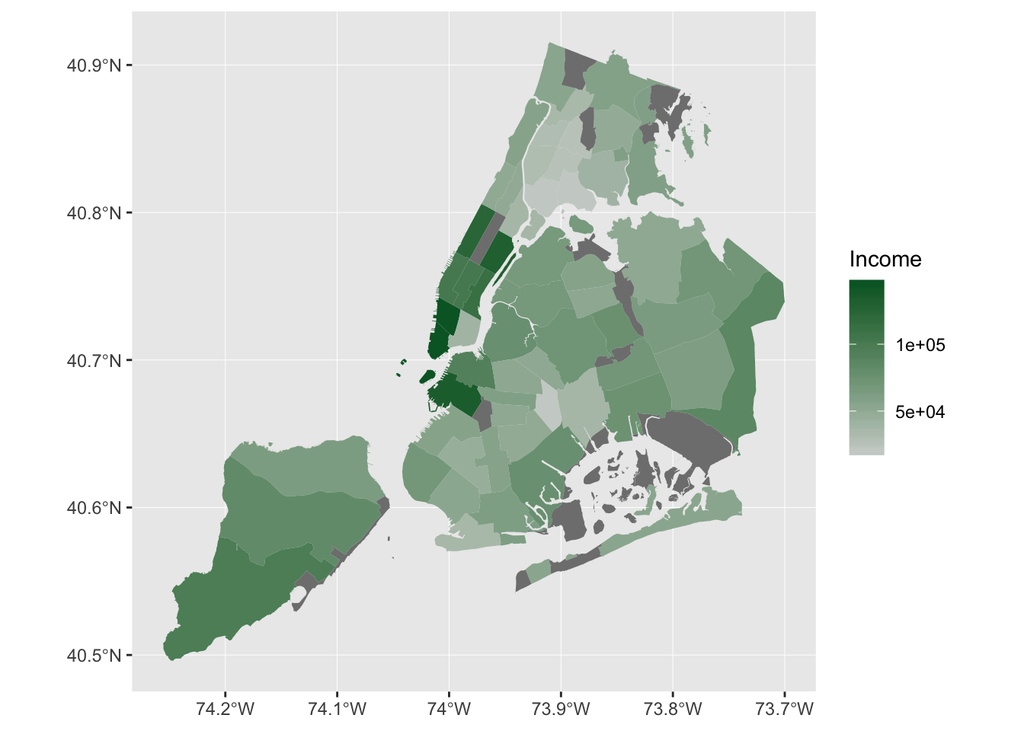

# Let’s Connect!

Github: kamalabdel97

Linkedin: [Kamal Abdelrahman](http://www.linkedin.com/in/KamalAbdel)